# Out with the old…

You've already seen how to construct basic plots

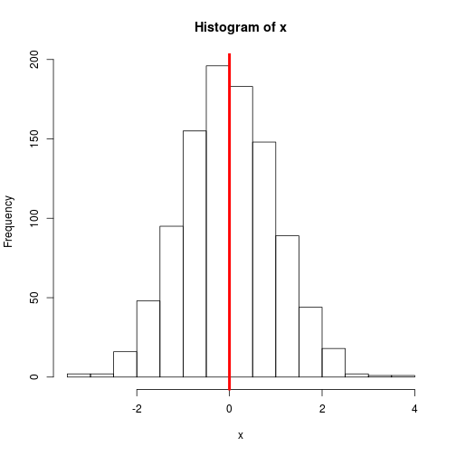

```r
x <- rnorm(n = 1000, mean = 0, sd = 1)

hist(x = x, breaks = 20)
abline(v = 0, col = "red", lwd = 4)
```

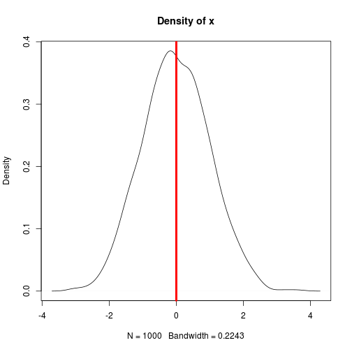

```r
plot(density(x), main = "Density of x")
abline(v = 0, col = "red", lwd = 4)
```

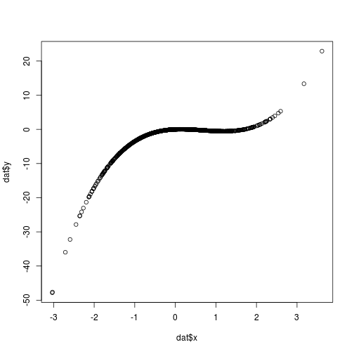

```r
y <- x^3 - 2 * x^2 + 0.5 * x

dat <- arrange(data.frame(x, y), x)
plot(dat$x, dat$y, type = "p")
```

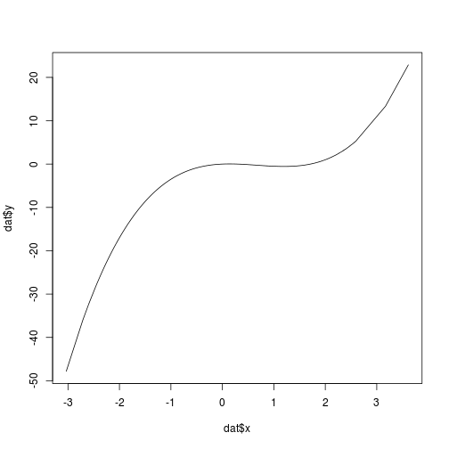

```r
plot(dat$x, dat$y, type = "l")
```

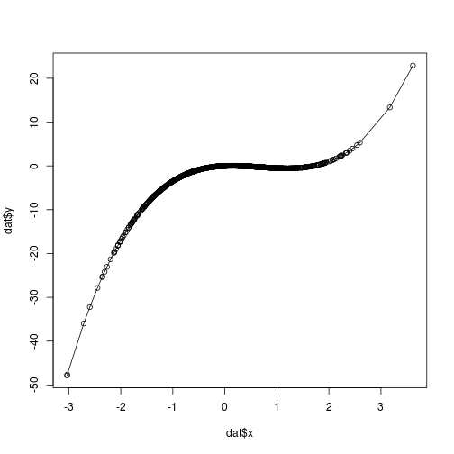

```r
plot(dat$x, dat$y, type = "o")
```

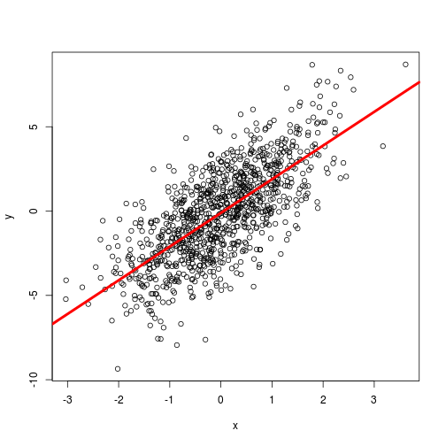

```r
y <- 2 * x + rnorm(n = length(x), mean = 0, sd = 2)
reg <- lm(y ~ x)
plot(x, y)
abline(reg, col = "red", lwd = 4)
```

And so on…

# Out with the old…

# … in with the new!

-lattice (Deepayan Sarkar, ISI, Delhi)

-ggplot2 (Hadley Wickham, again)

- Both are built on “grid”, both are really huge improvements over base R graphics
- Both also have entire *books* written about them (~200-300 pp.)

# lattice v. ggplot2

- lattice is

a) faster (though only noticeable over many and large plots),

b) simpler (at first),

c) better at trellis graphs

d) able to do 3d graphs

- ggplot2 is

a) generally more elegant,

b) more syntactically logical (and therefore simpler, once you learn it),

c) better at grouping

d) able to interface with maps

# First, some data

Armingeon et al., *Comparative Political Data Set I*, (2012)

```r
colnames(mydata)
```

```
## [1] "year"      "country"   "vturn"     "outlays"   "realgdpgr" "unemp"
```

# Basic usage: lattice

The general call for lattice graphics looks something like this:

```r
graph_type(formula, data=    , [options])
```

The specifics of the formula differ for each graph type, but the general format is straightforward

```r
x  # Show the distribution of x

x ~ y  # Show the relationship between x and y

x ~ y | A  # Show the relationship between x and y conditional on the values of A

x ~ y | A * B  # Show the relationship between x and y conditional on the combinations of values in A and B

z ~ y * x  # Show the 3D relationship between x, y, and z
```

# Basic usage: ggplot2

The general call for ggplot2 graphics looks something like this:

```r
ggplot(data=      , aes(x=    ,y=      , [options]))+geom_xxxx()+...+...+...
```

Note that ggplot2 graphs in layers (hence the endless +…+…+…), which really makes the extra layer part of the call

```r
...+geom_xxxx(data=      , aes(x=     ,y=     ,[options]),[options])+...+...+...
```

You can see the layering effect by comparing the same graph with different colors for each layer

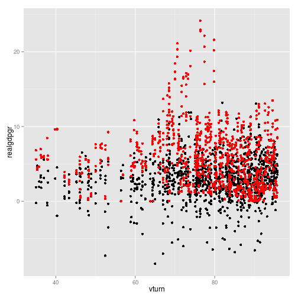

```r
ggplot(data = mydata, aes(x = vturn, y = realgdpgr)) + geom_point(color = "black") +
    geom_point(data = mydata, aes(x = vturn, y = unemp), color = "red")
```

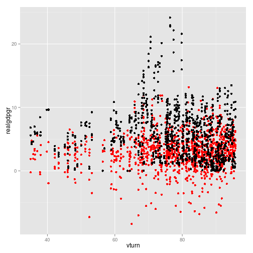

```r
ggplot(data = mydata, aes(x = vturn, y = realgdpgr)) + geom_point(color = "red") +
    geom_point(data = mydata, aes(x = vturn, y = unemp), color = "black")
```

# lattice v. ggplot2: Kernel Densities

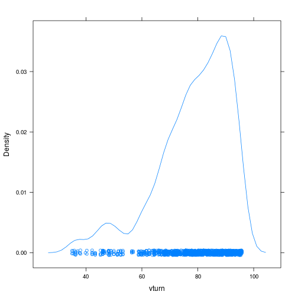

```r
densityplot(~vturn, data = mydata)  # lattice
```

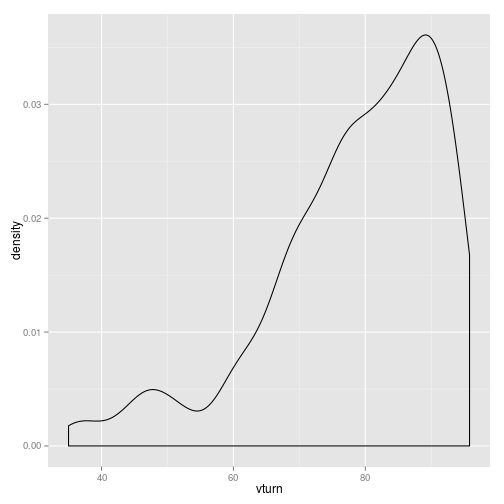

```r
ggplot(data = mydata, aes(x = vturn)) + geom_density()  # ggplot2
```

# lattice v. ggplot2: X-Y scatter plots

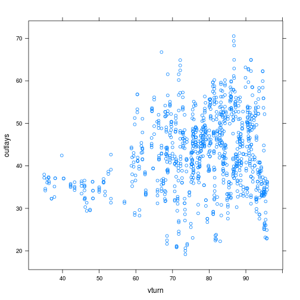

```r
xyplot(outlays ~ vturn, data = mydata)  #lattice
```

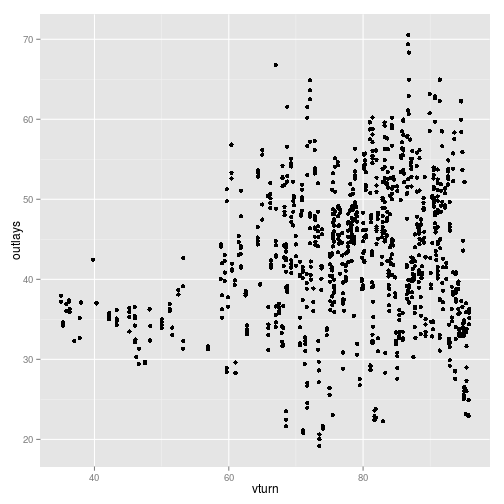

```r
ggplot(data = mydata, aes(x = vturn, y = outlays)) + geom_point()  # ggplot2
```

# lattice v. ggplot2: X-Y line plots

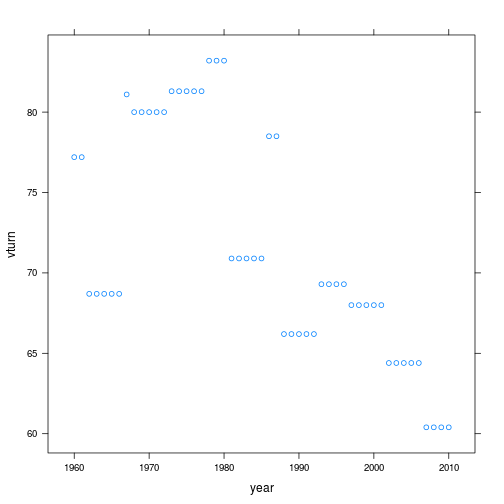

```r
xyplot(vturn ~ year, data = mydata, subset = mydata$country == "France")  #lattice (points)
```

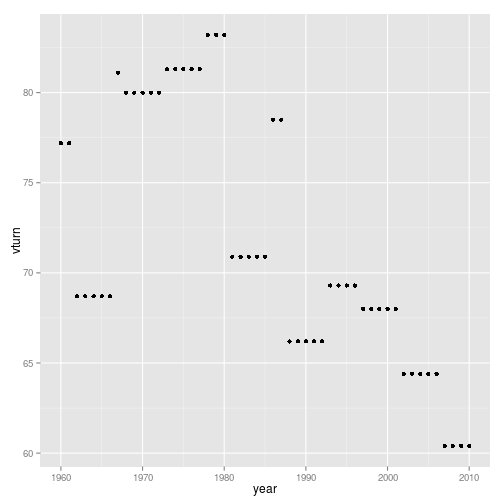

```r
ggplot(data = subset(x = mydata, subset = country == "France", select = c("vturn",
    "year")), aes(x = year, y = vturn)) + geom_point()  # ggplot2 (points)
```

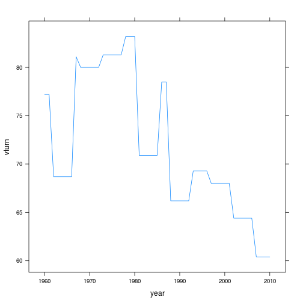

```r
xyplot(vturn ~ year, data = mydata, subset = mydata$country == "France", type = "l")  #lattice (line)
```

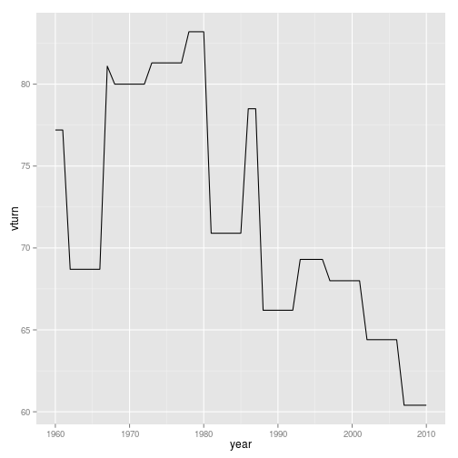

```r
ggplot(data = subset(x = mydata, subset = country == "France", select = c("vturn",
    "year")), aes(x = year, y = vturn)) + geom_line()  # ggplot2 (line)
```

# lattice v. ggplot2: “trellis” plots

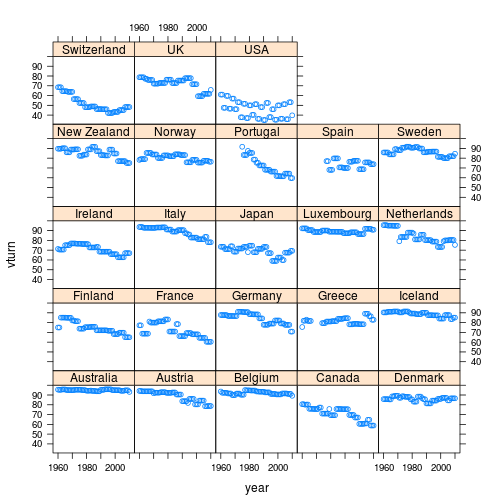

```r
xyplot(vturn ~ year | country, data = mydata)  #lattice
```

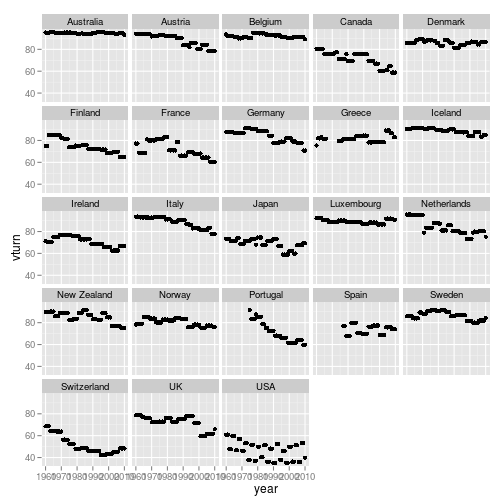

```r
ggplot(data = mydata, aes(x = year, y = vturn)) + geom_point() + facet_wrap(~country)  #ggplot2
```

# lattice v. ggplot2: countour plots

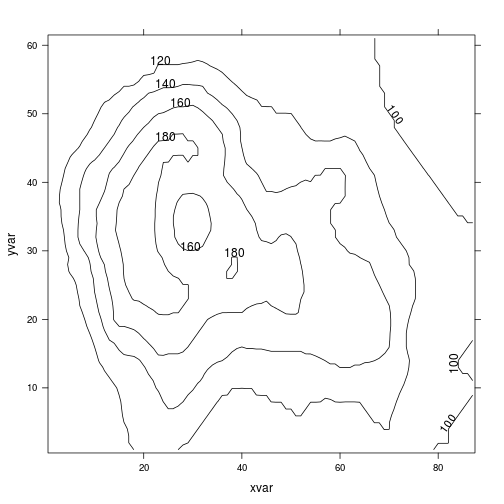

```r
data(volcano)
volcano3d <- melt(volcano)
names(volcano3d) <- c("xvar", "yvar", "zvar")
contourplot(zvar ~ xvar + yvar, data = volcano3d)  #lattice
```

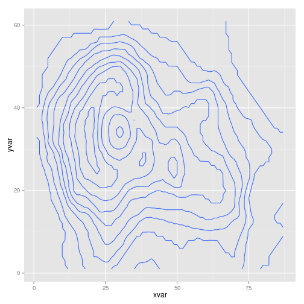

```r
ggplot(data = volcano3d, aes(x = xvar, y = yvar, z = zvar)) + geom_contour()  #ggplot2
```

# lattice v. ggplot2: tile/image plots

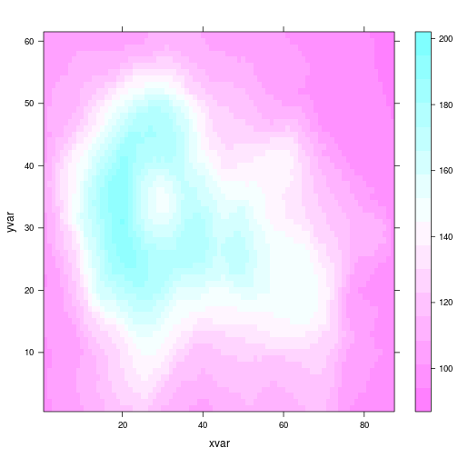

```r
data(volcano)
volcano3d <- melt(volcano)
names(volcano3d) <- c("xvar", "yvar", "zvar")
levelplot(zvar ~ xvar + yvar, data = volcano3d)  #lattice
```

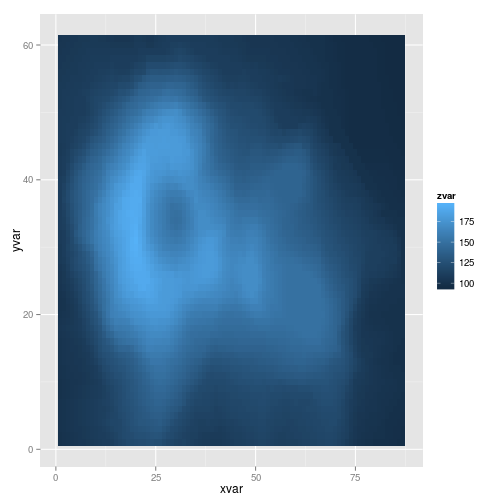

```r
ggplot(data = volcano3d, aes(x = xvar, y = yvar, z = zvar)) + geom_tile(aes(fill = zvar))  #ggplot2
```

# lattice: 3D plots

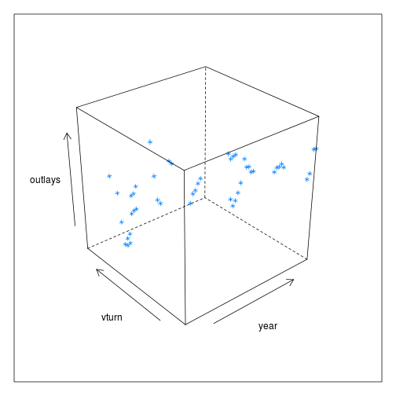

```r
cloud(outlays ~ year * vturn, data = mydata, subset = mydata$country == "France")
```

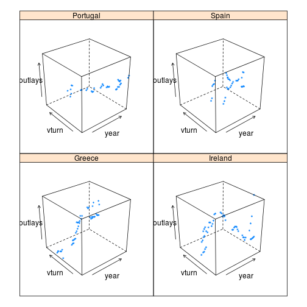

```r
cloud(outlays ~ year * vturn | country, data = mydata, subset = is.element(mydata$country,
    c("Greece", "Portugal", "Ireland", "Spain")) == T)
```

# ggplot2: Groups in a single pane

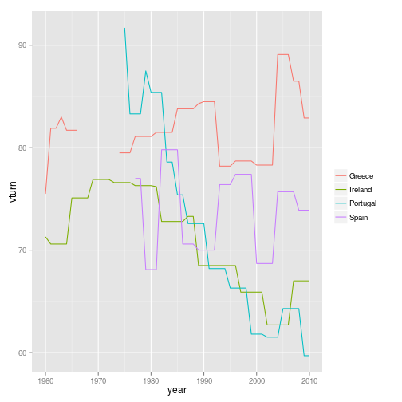

```r
mydata.subset <- subset(x = mydata, subset = is.element(country, c("Greece",
    "Portugal", "Ireland", "Spain")), select = c("year", "country", "vturn",
    "realgdpgr"))

ggplot(data = mydata.subset, aes(x = year, y = vturn, color = )) + geom_line(aes(color = country))
```

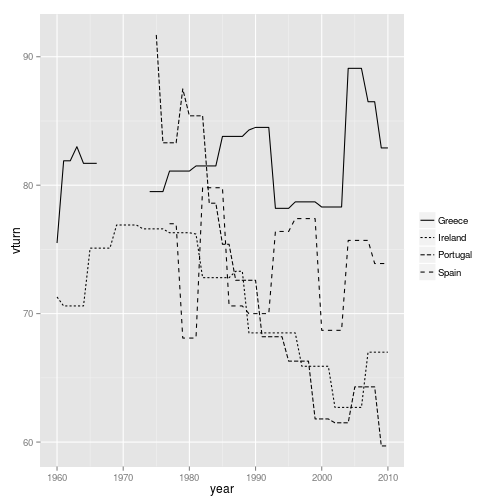

```r
ggplot(data = mydata.subset, aes(x = year, y = vturn, linetype = )) + geom_line(aes(linetype = country))
```

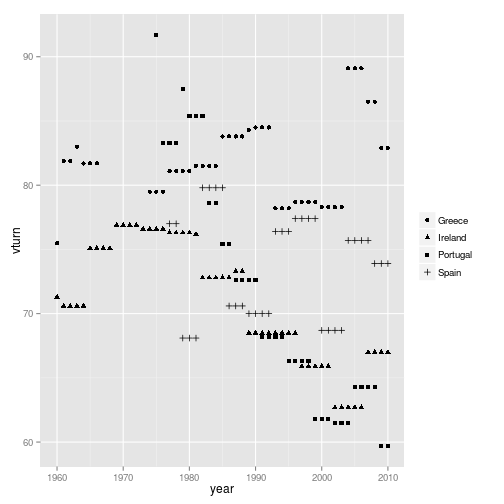

```r
ggplot(data = mydata.subset, aes(x = year, y = vturn, shape = )) + geom_point(aes(shape = country))
```

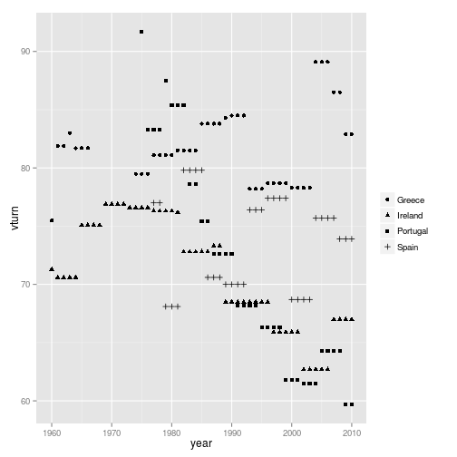

```r
ggplot(data = mydata.subset, aes(x = year, y = vturn, shape = )) + geom_point(aes(shape = country))
```

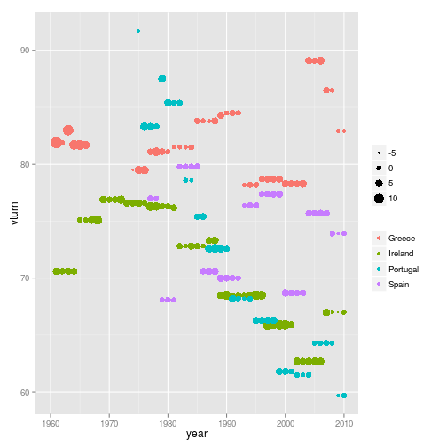

```r
ggplot(data = mydata.subset, aes(x = year, y = vturn, color = , size = )) +
    geom_point(aes(color = country, size = realgdpgr))
```

# ggplot2 and the Grammar of Graphics

- By now, you might be noticing some trends in how these two packages approach graphics
- lattice tends to focus on a particular type of graph and how to represent cross-sectional variation by splitting it up into smaller chunks
- Becoming a proficient user of lattice requires learning a huge array of graph-specific formulas and options
- ggplot2 tries to represent much more of the cross-sectional variation by making use of various “aesthetics”; general approach is based on *The Grammar of Graphics*

# ggplot2, aesthetics, and the Grammar of Graphics

- Basic idea is that the visualization of all data requires four items

1) One or more **statistics** conveying information about the data (identities, means, medians, etc.)

2) A **coordinate system** that differentiates between the intersections of statistics (at most two for ggplot, three for lattice)

3) **Geometries** that differentiate between off-coordinate variation in *kind*

4) **Scales** that differentiate between off-coordinate variation in *degree*

- ggplot2 allows the user to manipulate all four of these items

# Anatomy of aes()

```r
ggplot(data = , aes(x = , y = , color = , linetype = , shape = , size = ))
```

Can you see how the different aesthetic types have been implemented?

# Titles, labels, options, etc.

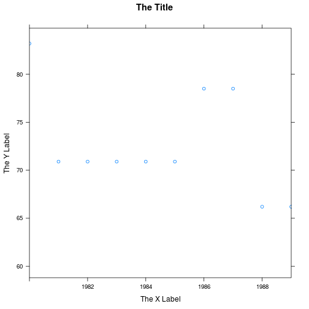

```r
xyplot(vturn ~ year, data = mydata, subset = mydata$country == "France", xlab = "The X Label",
    ylab = "The Y Label", xlim = c(1980, 1989), main = "The Title")  #lattice (points)
```

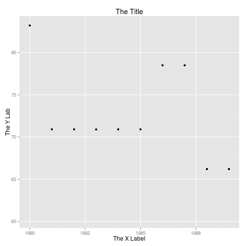

```r
ggplot(data = subset(x = mydata, subset = country == "France", select = c("vturn",
    "year")), aes(x = year, y = vturn)) + geom_point() + xlab(label = "The X Label") +
    ylab(label = "The Y Lab") + xlim(1980, 1989) + ggtitle(label = "The Title")  # ggplot2 (points)
```

# Combining many plots

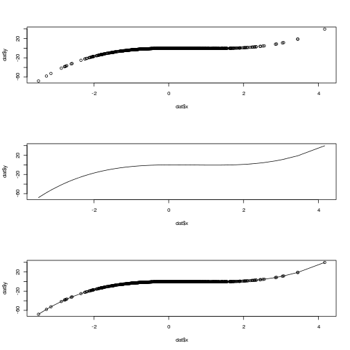

```r
x <- rnorm(n = 1000, mean = 0, sd = 1)
y <- x^3 - 2 * x^2 + 0.5 * x

dat <- arrange(data.frame(x, y), x)
par(mfrow = c(3, 1))
plot(dat$x, dat$y, type = "p")
plot(dat$x, dat$y, type = "l")
plot(dat$x, dat$y, type = "o")
```

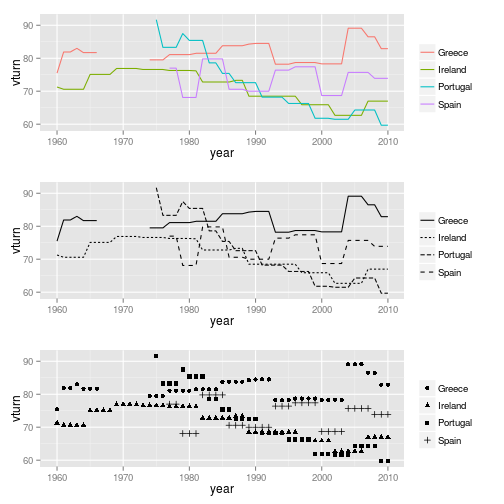

```r
plot1 = ggplot(data = mydata.subset, aes(x = year, y = vturn, color = )) + geom_line(aes(color = country))
plot2 = ggplot(data = mydata.subset, aes(x = year, y = vturn, linetype = )) +
    geom_line(aes(linetype = country))
plot3 = ggplot(data = mydata.subset, aes(x = year, y = vturn, shape = )) + geom_point(aes(shape = country))
grid.arrange(plot1, plot2, plot3, nrow = 3, ncol = 1)
```

# Exporting your fancy graphics

Two basic image types

1) Raster/Bitmap (.png, .jpeg)

Every pixel of a plot contains its own separate coding; not so great if you want to resize the image

```r
jpeg(filename = "bah.png", width = , height = )
plot(x, y)
dev.off()
```

2) Vector (.pdf, .ps)

Every element of a plot is encoded with a function that gives its coding conditional on several factors; great for resizing

```r
pdf(filename = "bah.pdf", width = , height = )
plot(x, y)
dev.off()
```

# Exporting your fancy graphics with ggplot

```r
ggsave(filename = , plot = , scale = , width = , height = )
```

# Breakout!

- Two-part breakout

1) Not all variable types are suitable for representation by every ggplot aesthetic. What kinds of variables can the aesthetics color, size, and shape meaningfully represent?

2) ggplot graphics are often layered, with some data represented by a set of aesthetics being overlayed upon a different combination of data and aesthetics. Can you fit simple linear trend lines to every facet of the grided voter turnout graph? Hint: use a simple linear regression and consult ?geom_smooth